# Intro to R4DS

08/03/2023

## WSAFE589-23A (HAM)

### R for Data Science

## About me

Ben Marmont (Lecturer)

- Economist at DairyNZ
- Master of Management (Economics) from University of Waikato
- Carpentries qualified instructor (R)

## About the course

- Schedule
  - All online, recordings available
  - Email to make an appointment for office hours

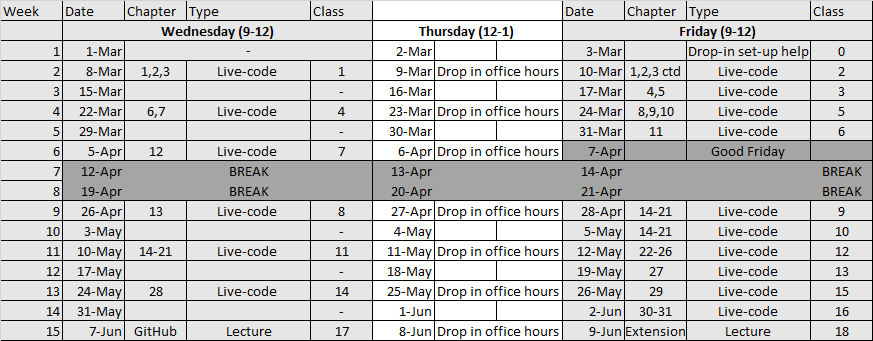

## Content

- R for Data Science Second edition ([R4DS](https://r4ds.hadley.nz/))
  - [Hadley Wickham](https://hadley.nz/) is from NZ and is now the Chief Scientist at RStudio (hopefully you recognize that name!) and author of four open access books to help people learn R all the way through to advanced extension skills.
- Data science in the tidyverse

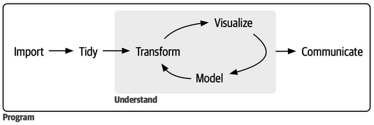

## Pedagogy

[Inspired by the carpentries](https://orchid00.github.io/The_Carpentries_info/overview-of-carpentries-pedagogic-model.html)

- Active learning (practice) is key, this course will have minimal components where I speak to you i.e. lecture. Instead, we will utilise ‘live coding’.
  - Live coding will show you my workflow, my mistakes (everyone makes them) and how I troubleshoot them!
  - When you run into difficulty utilise the chat in class, communicating with others is key to understanding
  - Spaced retrieval
  - Managed cognitive load

## Assessments

These will be made available as we get closer to the time, more information on moodle.

- 1: Basic Data Analysis, due 3/4/23
- 2: Visualisation, due 17/5/23
- 3: Online Timed Assessment, 48 hours 9/6/23 - 11/6/23
- 4: Data retrieval and modelling, due 22/6/23

## How to find help?

- Collaboration forum (moodle)
- The chat during lectures (on wednesday ask your peers, on Michael will be in the chat)
- Chat GPT
- Office hours (email Michael for appointment)

## Resources (links imbedded):

- Moodle [log in here](https://www.waikato.ac.nz/)
- [Textbook](https://r4ds.hadley.nz/)
  - The first iteration of the textbook has a significantly different order of content
- Ben’s [GitHub repository](https://github.com/BenMarmont/waikato_r4ds_2023)

## What about you?

- Round table:
  - Name
  - Role
  - Reason for doing this course